```python
%%shell
jupyter nbconvert --to html "/content/CM_3015_Benjamin_Lee_EndTerms.ipynb"
```

```
[NbConvertApp] Converting notebook /content/CM_3015_Benjamin_Lee_EndTerms.ipynb to html
[NbConvertApp] Writing 1461852 bytes to /content/CM_3015_Benjamin_Lee_EndTerms.html
```

# CM3015

## Machine Learning Neural Network CW2

## Lee Chang Loong Benjamin

### uol id: 220516503

# 1.Introduction

This report aims to explore multiclass image classification problems, specifically using the [MNIST dataset](https://www.tensorflow.org/datasets/catalog/mnist). Following [François Chollet's universal workflow from "Deep Learning with Python,](https://livebook.manning.com/book/deep-learning-with-python/chapter-4/161)" we strive for a systematic approach to develop, evaluate, and refine our model.

# 2.Problem statement and Dataset

We tackle the MNIST dataset's classification challenge, aiming to accurately categorize 28x28 pixel images of handwritten digits into one of ten classes (digits 0 through 9). Given the stationary nature of this problem, we anticipate reliable model performance across similar unseen data.

# 2.1 Hypothesis and Dataset Rationale

I theorize that a strong predictive relationship exists between an image's pixel values and the label it represents, enabling precise classification. This theory rests on the idea that a model can learn patterns within the pixel data to differentiate between digit classes. I chose the TensorFlow-provided MNIST dataset because of its diversity and size, which support effective model training. It includes 60,000 training images and 10,000 for testing, each digit (0-9) represented in a roughly 6000:1000 split within the training and testing sets.

Because the MNIST dataset has balanced class distribution, accuracy will be the main way to judge the model. Precision and recall are also important, especially when there's class imbalance, but less essential in this scenario. Still, they'll help analyze the model's performance, like finding biases towards certain classes or if different classes have heavily varying false-positive/negative costs.

# 3. Establishing an evaluation method: Hold-Out Validation

To ensure that a rigorious and fair assessment of my model's performance is employed, i will employ hold-out validation as the evaluation protocol. This method shall involve setting aside a portion of the training data to create a validation set,which is not used during the model's learning phase but instead plays a role of evaluating the model's predictions and monitoring of its performance during the training process.

# 4 Data Preparation

## 4.1 MNIST Dataset loading phase

```python
!pip install tensorflow-datasets -q
!pip install tensorflow -q
!pip install opencv-python
```

```python
import tensorflow as tf
from tensorflow.keras.datasets import mnist as dataset_mnist
from tensorflow.keras.preprocessing.image import ImageDataGenerator
from tensorflow.keras.utils import to_categorical as to_one_hot
from tensorflow.keras import layers, models,regularizers
from tensorflow.keras.models import Sequential as Model_Sequence
from tensorflow.keras.layers import Flatten, Dense, Dropout
from tensorflow.keras.callbacks import EarlyStopping as Stop_Early
from tensorflow.keras.optimizers import RMSprop as Optimizer_RMSprop

import numpy as np
import matplotlib.pyplot as plt
from sklearn.model_selection import train_test_split as split_data
from collections import Counter
import cv2

# This allows us to reproduce the results from our script
tf.random.set_seed(42)
np.random.seed(42)
```

## 4.2 MNIST Data Sample

```
Downloading data from https://storage.googleapis.com/tensorflow/tf-keras-datasets/mnist.npz
Train: X=(60000, 28, 28), y=(60000,)
Test: X=(10000, 28, 28), y=(10000,)
```

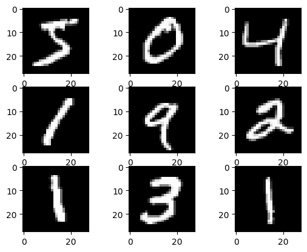

```python
# Load MNIST Dataset
(X_features_train, y_labels_train), (X_features_test, y_labels_test) = dataset_mnist.load_data()
  # Dataset Summary

print('Train: X=%s, y=%s' % (X_features_train.shape, y_labels_train.shape))
print('Test: X=%s, y=%s' % (X_features_test.shape, y_labels_test.shape))
# Sample plot showing images in a (28, 28) 2d array
for i in range(9):
 plt.subplot(330 + 1 + i)
 plt.imshow(X_features_train[i], cmap=plt.get_cmap('gray'))

plt.show()
```

The pixel values in the images range from 0 to 255. We normalize these values to a range of 0 to 1, a process that helps speed up the training by ensuring that our optimization algorithm works efficiently. This is done by dividing the pixel values by 255

```python
#Normalizing the pixel values
X_features_train, X_features_test = X_features_train / 255.0, X_features_test / 255.0
```

## 4.3.One-Hot Encoding the Labels:

The labels for my images are currently integers representing the digits. To prepare these for classification, we convert them into one-hot encoded vectors - a form where the label is represented as a 10-dimensional vector (for the 10 possible digit classes), with a 1 in the position of the correct digit and 0s elsewhere. This is achieved via Tensorflow's [**to_categorical() utility function**](https://www.geeksforgeeks.org/python-keras-keras-utils-to_categorical/).

```python
# Applying One-Hot Encoding to Digit Labels
y_labels_train_oh = to_one_hot(y_labels_train, num_classes=10)
y_labels_test_oh = to_one_hot(y_labels_test, num_classes=10)
```

## 4.4 Preparing the Hold-Out Validation Set

```python
# Preparing a Validation Set for Model Tuning
X_train_final, X_val, y_train_final, y_val = split_data(X_features_train, y_labels_train_oh, test_size=0.2,random_state =42)
```

# 5. Model Development and Baseline Establishment

In adherence to Chollet's DLWP, surpassing the baseline performance in MNIST image classification embodies not just exceeding a mere 10% accuracy-- which represents the threshold of random chance given ten classes-- but substantially excelling beyond this point. My goal is to create a neural network model that leverages the structured relationships between the pixel values and their corresponding values to **significantly** exceed this baseline.

*Architectural choices:*

Last-Layer Activation: The softmax function is selected for its proficiency in outputting a probability distribution across the ten classes, aligning perfectly with the multiclass nature of my task.

Loss Function: Categorical crossentropy is my choice here, apt for evaluating the accuracy of predictions across multiple categories by comparing the predicted probability distribution against the actual distribution of labels.

Optimizer: RMSprop, known for its effectiveness in adjusting the learning rate automatically, ensures my model trains efficiently, making it a preferred optimizer for our setup.

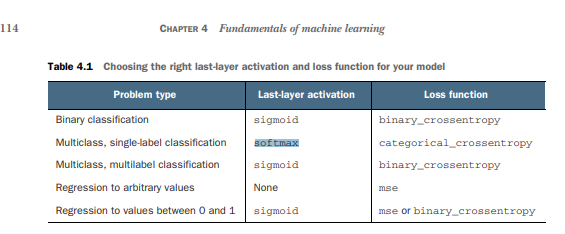

Reference from page 114 of DLWP "Choosing the right last-layer activation and loss function for your model"

## 5.1 Establishing Naive Class Baseline

Before diving into model building, its eseential to set the baseline for comparison. For this, i will consider a Naive Majority Class Baseline, which assumes the most frequent class in the training set as prediction for all instances. This approach give an initial benchmark for the model's performance.

```python
# Convert one-hot encoded labels back to integer labels for counting
y_labels_train_int = np.argmax(y_labels_train_oh, axis=1)

# Count the number of samples for each label in the training set
highest_label = Counter(y_labels_train).most_common(1)[0][0]
highest_label_count = Counter(y_labels_train).most_common(1)[0][1]


naive_y_pred = highest_label_count / len(y_labels_test_oh)


print("Label with most samples in the training set:")
print("Digit: %s, w/ count of %s samples" % (highest_label, highest_label_count))

print("Naive Baseline Accuracy: {:0.2f}%".format(naive_y_pred * 100))
```

```
Label with most samples in the training set:
Digit: 1, w/ count of 6742 samples
Naive Baseline Accuracy: 67.42%
```

This is now our baseline accuracy to work with to develop the new model

```python
# Model architecture
baseline_model = Model_Sequence([
    Flatten(input_shape=(28, 28)),     # Flattens the input to a 1D array
    Dense(128, activation='relu'),      # First dense layer with ReLU activation
    Dense(10, activation='softmax')                  # Output layer with softmax activation for classification

], name='baseline_model')

# Compile the model with the rmsprop optimizer and categorical crossentropy loss
baseline_model.compile(optimizer=Optimizer_RMSprop(),
              loss='categorical_crossentropy',
              metrics=['accuracy'])
# Display the model's architecture
baseline_model.summary()
```

```
Model: "baseline_model"
_________________________________________________________________
 Layer (type)                Output Shape              Param #
=================================================================
 flatten (Flatten)           (None, 784)               0

 dense (Dense)               (None, 128)               100480

 dense_1 (Dense)             (None, 10)                1290

=================================================================
Total params: 101770 (397.54 KB)
Trainable params: 101770 (397.54 KB)
Non-trainable params: 0 (0.00 Byte)
_________________________________________________________________
```

```python
# Compile the model with RMSprop optimizer
baseline_model.compile(optimizer='rmsprop',  # Using RMSprop optimizer
              loss='categorical_crossentropy',
              metrics=['accuracy'])

# Training the baseline model
history_baseline = baseline_model.fit(X_train_final, y_train_final,
                 epochs=5, batch_size=64,
                 validation_data=(X_val, y_val),
                 callbacks=[Stop_Early(monitor='val_loss', patience=3, restore_best_weights=True)])



# Evaluating the model on the test set
test_loss_base, test_accuracy_base = baseline_model.evaluate(X_features_test, y_labels_test_oh)
print(f'Test accuracy: {test_accuracy_base*100:.2f}%')
```

```
Test accuracy: 97.30%
```

```python
def visualize_training_loss(hist_data):
    """
    Visualizes training and validation loss.

    Parameters:
    hist_data (History): Training history of the model.
    """
    train_loss, val_loss = hist_data.history['loss'], hist_data.history['val_loss']
    epochs = range(1, len(train_loss) + 1)

    plt.figure(figsize=(8, 5))
    plt.plot(epochs, train_loss, 'b-', label='Training Loss')
    plt.plot(epochs, val_loss, 'r', label='Validation Loss')
    plt.title('Training and Validation Loss')
    plt.xlabel('Epochs')
    plt.ylabel('Loss')
    plt.legend()
    plt.grid(True)
    plt.show()
```

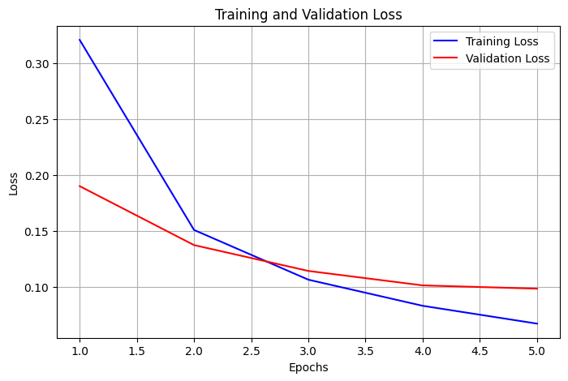

```python
visualize_training_loss(history_baseline)
```

```python
def visualize_training_accuracy(hist_data):
    """
    Visualizes training and validation accuracy.

    Parameters:
    hist_data (History): Training history of the model.
    """
    train_accuracy, val_accuracy = hist_data.history['accuracy'], hist_data.history['val_accuracy']
    epochs = range(1, len(train_accuracy) + 1)

    plt.figure(figsize=(8, 5))
    plt.plot(epochs, train_accuracy, 'b-', label='Training Accuracy')
    plt.plot(epochs, val_accuracy, 'r', label='Validation Accuracy')
    plt.title('Training and Validation Accuracy')
    plt.xlabel('Epochs')
    plt.ylabel('Accuracy')
    plt.legend()
    plt.grid(True)
    plt.show()
```

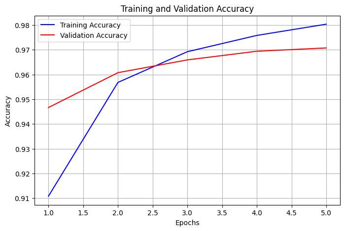

```python
visualize_training_accuracy(history_baseline)
```

```python
# validate base model accuracy against naive baseline
base_model_scores = baseline_model.evaluate(X_features_test, y_labels_test_oh, verbose=0)[1:]

print('(Accuracy (Validation Set): {:.2f}%) (Majority Class (Naive Baseline): {:.2f}%)'.format(base_model_scores[0] * 100, naive_y_pred * 100))
```

```
(Accuracy (Validation Set): 97.30%) (Majority Class (Naive Baseline): 67.42%)
```

Here, my trained model not only surpasses the naive baseline, showing superior statistical power, but also attaining a accuracy greater than 10%. This accomplishment validates my initial hypothesis , confirming that i can predict outcomes based on given inputs, and indicates a predictive relationship between the data. the new model satisfies the following two conditions:

1. achieving better satistical power
2. having better accuracy

# 7. Developing an overfitting model

To ensure our model performs optimally, we need to find the sweet spot between overfitting and underfitting. Here are three ways to check for that:

- Add layers: Increasing model complexity can help it learn more intricate patterns
- Make layers bigger: Expanding layers (more neurons) provides the model with greater capacity to capture relationships.
- Train for more epochs: Additional training allows the model to refine its understanding of the data

```python
# Adding more layers and units to intentionally overfit
overfit_model = Model_Sequence([
    Flatten(input_shape=(28, 28)),
    Dense(256, activation='relu'),
    Dense(128, activation='relu'),
    Dense(128, activation='relu'),
    Dense(64, activation='relu'),
    Dense(10, activation='softmax')
], name='overfit_model')

overfit_model.summary()
```

```
Model: "overfit_model"
_________________________________________________________________
 Layer (type)                Output Shape              Param #
=================================================================
 flatten_1 (Flatten)         (None, 784)               0

 dense_2 (Dense)             (None, 256)               200960

 dense_3 (Dense)             (None, 128)               32896

 dense_4 (Dense)             (None, 128)               16512

 dense_5 (Dense)             (None, 64)                8256

 dense_6 (Dense)             (None, 10)                650

=================================================================
Total params: 259274 (1012.79 KB)
Trainable params: 259274 (1012.79 KB)
Non-trainable params: 0 (0.00 Byte)
_________________________________________________________________
```

```python
overfit_model.compile(optimizer=Optimizer_RMSprop(),
              loss='categorical_crossentropy',
              metrics=['accuracy'])

# Training the overfit model with more epochs to ensure overfitting
history_overfit = overfit_model.fit(X_train_final, y_train_final,
                 epochs=20, batch_size=64,
                 validation_data=(X_val, y_val))

#evaluate model on validation set
test_loss, test_acc = overfit_model.evaluate(X_val, y_val)
print('Validation Accuracy: {:.2f}%'.format(test_acc * 100))
```

```
Validation Accuracy: 98.09%
```

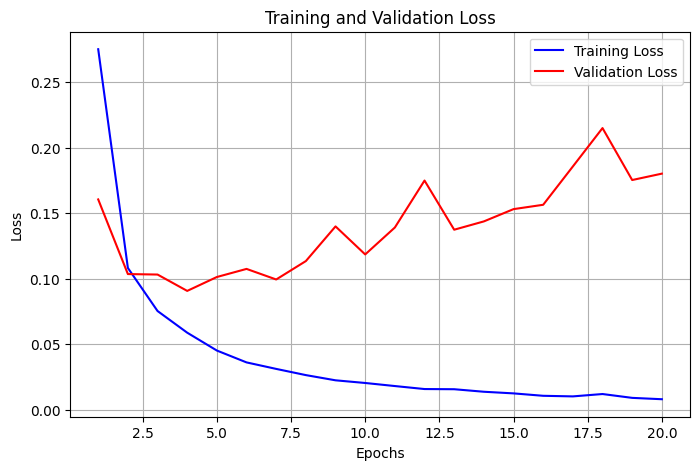

```python
# Plotting to observe overfitting
visualize_training_loss(history_overfit)
```

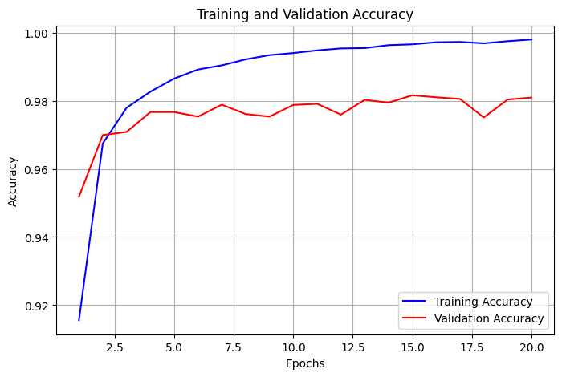

```python
#plotting to observe overfitting
visualize_training_accuracy(history_overfit)
```

# 8. Regularizing the Overfit Model

Now that a baseline model and an overfitting counterpart have been established, the next phase involves systematic hyperparameter tuning. Strategies include:

- Selective Neuron Deactivation: Evaluation of dropout techniques to encourage generalization.
- Layer Modifications: Exploration of the effects of adding or removing layers on performance and overfitting tendencies.
- Regularization Implementation: Application of L1 and/or L2 regularization to constrain model complexity.
- Hyperparameter Optimization: Exploration of adjustments to units per layer, learning rate, and other hyperparameters.

Through these processes, it will help me develop a acceptable model configuration where it is a good fit and the [training and validation loss both decreases and stablizes at a specific point.](https://medium.com/@penpencil.blr/what-is-the-difference-between-training-loss-validation-loss-and-evaluation-loss-c169ddeccd59)

## 8.1 Reducing the number of Epochs

To assist us in achieving this, a function has been developed that returns the training epoch with the lowest validation loss.

```python
def find_optimal_epoch(training_history):
    """
    Identifies the optimal epoch number where the validation loss was minimum.

    Parameters:
    training_history (dict): A dictionary containing the training history of the model,
                             specifically 'val_loss' for the validation loss over epochs.

    Returns:
    int: The epoch number (1-indexed) where the validation loss was at its lowest.
    """

    # Check if 'val_loss' is in the history dictionary
    if 'val_loss' not in training_history:
        print("Validation loss not found in training history.")
        return None

    # Find the index of the minimum validation loss
    min_loss_index = np.argmin(training_history['val_loss'])

    # Convert to 1-indexed epoch number
    optimal_epoch = min_loss_index + 1

    print(f"Minimum validation loss reached in epoch: {optimal_epoch}")
    return optimal_epoch
```

```python
# Example usage
optimal_epoch_number = find_optimal_epoch(history_overfit.history)
print("Optimal Epoch:", optimal_epoch_number)
```

```
Minimum validation loss reached in epoch: 4
Optimal Epoch: 4
```

```python
EpochModel = Model_Sequence([
                    Flatten(input_shape=(28, 28)),
                    Dense(128, activation='relu'),
                    Dense(64, activation='relu'),
                    Dropout(0.5), # Add dropout after first two dense layers
                    Dense(48, activation='relu'),
                    Dense(16, activation='relu'),
                    Dense(10, activation='softmax')
], name='EpochModel')

EpochModel.summary()

EpochModel.compile(optimizer='rmsprop',
              loss='categorical_crossentropy',
              metrics=['accuracy'])

#training the model with four epochs
EpochModel_history = EpochModel.fit(X_train_final, y_train_final,
                                    epochs=optimal_epoch_number, batch_size=64,
                                    validation_data=(X_val, y_val))
```

```
Model: "EpochModel"
_________________________________________________________________
 Layer (type)                Output Shape              Param #
=================================================================
 flatten_2 (Flatten)         (None, 784)               0

 dense_7 (Dense)             (None, 128)               100480

 dense_8 (Dense)             (None, 64)                8256

 dropout (Dropout)           (None, 64)                0

 dense_9 (Dense)             (None, 48)                3120

 dense_10 (Dense)            (None, 16)                784

 dense_11 (Dense)            (None, 10)                170

=================================================================
Total params: 112810 (440.66 KB)
Trainable params: 112810 (440.66 KB)
Non-trainable params: 0 (0.00 Byte)
_________________________________________________________________
```

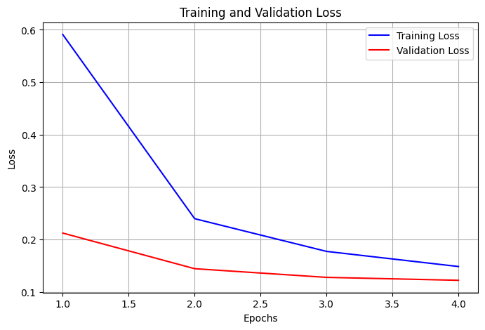

```python
visualize_training_loss(EpochModel_history)
```

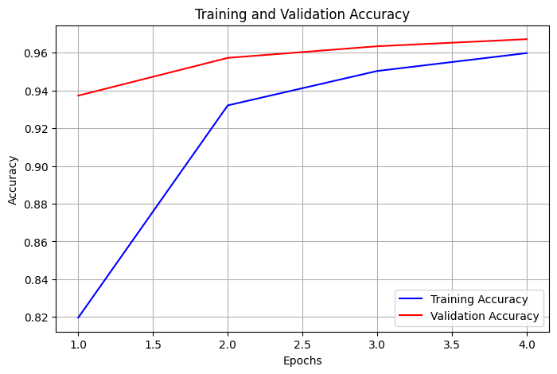

```python
#plotting to observe overfitting
visualize_training_accuracy(EpochModel_history)
```

## 8.2 Dropout Regularisation Application

Dropout Regularisation is an approach whereby certain nodes in each layer is randomly dropped or "disregarded". This is known as dropout and is typically implemented by [adding dropout layers into the neural network architecture](https://machinelearningmastery.com/dropout-regularization-deep-learning-models-keras/). The main benefit is its effective in reduce overfitting as it ensures that no units are codependant on each other.

```python
DropoutModel = Model_Sequence([
                    Flatten(input_shape=(28, 28)),
                    Dense(128, activation='relu'),
                    Dense(64, activation='relu'),
                    Dropout(0.3), # Add dropout of 0.3 after two dense layers
                    Dense(48, activation='relu'),
                    Dense(16, activation='relu'),
                    Dense(10, activation='softmax')
], name='DropoutModel')

DropoutModel.summary()

DropoutModel.compile(optimizer='rmsprop',
              loss='categorical_crossentropy',
              metrics=['accuracy'])
#training the model with four epochs
DropoutModel_history = EpochModel.fit(X_train_final, y_train_final,
                                    epochs=optimal_epoch_number, batch_size=64,
                                    validation_data=(X_val, y_val)
                                    )
```

```
Model: "DropoutModel"
_________________________________________________________________
 Layer (type)                Output Shape              Param #
=================================================================
 flatten_7 (Flatten)         (None, 784)               0

 dense_32 (Dense)            (None, 128)               100480

 dense_33 (Dense)            (None, 64)                8256

 dropout_12 (Dropout)        (None, 64)                0

 dense_34 (Dense)            (None, 48)                3120

 dense_35 (Dense)            (None, 16)                784

 dense_36 (Dense)            (None, 10)                170

=================================================================
Total params: 112810 (440.66 KB)
Trainable params: 112810 (440.66 KB)
Non-trainable params: 0 (0.00 Byte)
_________________________________________________________________
```

[figure not shown]

```python
visualize_training_loss(DropoutModel_history)
```

[figure not shown]

```python
visualize_training_accuracy(DropoutModel_history)
```

## 8.3 L2 Regularisation

In the next model,i will employ L2 regularisation, which will impose a penalty on the magnitude of the coefficients. [This technique discourages the model from relying too heavily on any individiual features by shrinking the weights](https://www.simplilearn.com/tutorials/machine-learning-tutorial/regularization-in-machine-learning), therefore mitigating the risk of overfitting and improves the models ability to generalise its predictions to new data.

```python
RegularisationModel = Model_Sequence([
                    Flatten(input_shape=(28, 28)),
                    Dense(128, activation='relu', kernel_regularizer=regularizers.l2(0.01)),#adding regularizer
                    Dense(64, activation='relu', kernel_regularizer=regularizers.l2(0.01)),
                    Dropout(0.5), # Add dropout
                    Dense(48, activation='relu', kernel_regularizer=regularizers.l2(0.01)),
                    Dense(16, activation='relu'),
                    Dense(10, activation='softmax')
], name='RegularisationModel')

RegularisationModel.summary()

RegularisationModel.compile(optimizer='rmsprop',
              loss='categorical_crossentropy',
              metrics=['accuracy'])

RegularisationModel_history = RegularisationModel.fit(X_train_final, y_train_final,
                                    epochs=optimal_epoch_number, batch_size=64,
                                    validation_data=(X_val, y_val)
                                    )
```

```
Model: "RegularisationModel"
_________________________________________________________________
 Layer (type)                Output Shape              Param #
=================================================================
 flatten_4 (Flatten)         (None, 784)               0

 dense_17 (Dense)            (None, 128)               100480

 dense_18 (Dense)            (None, 64)                8256

 dropout_5 (Dropout)         (None, 64)                0

 dense_19 (Dense)            (None, 48)                3120

 dense_20 (Dense)            (None, 16)                784

 dense_21 (Dense)            (None, 10)                170

=================================================================
Total params: 112810 (440.66 KB)
Trainable params: 112810 (440.66 KB)
Non-trainable params: 0 (0.00 Byte)
_________________________________________________________________
```

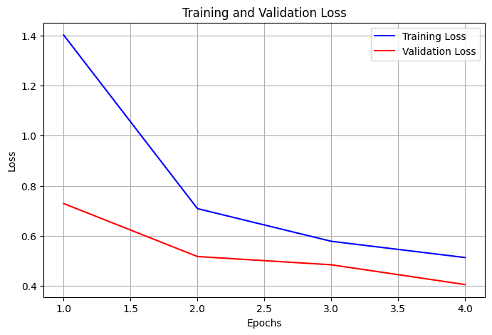

```python
visualize_training_loss(RegularisationModel_history)
```

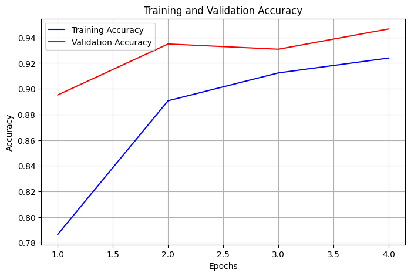

```python
visualize_training_accuracy(RegularisationModel_history)
```

I can see here that Adding L2 Regularisation has widened the curve of the model and may not be the best regularisation method for this case.

# 9.Comparison & Conclusion

Throughout the model training process, I implemented several strategies to achieve a good fit between training and validation performance. Tuning the models to optimize the parameters was the most time-intensive part, especially due to the lengthy epoch durations required for training.

## 9.1 Baseline Neural Model Results

```
Validation Accuracy: 97.30%
```

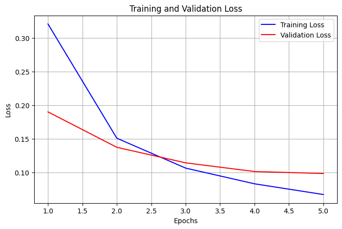

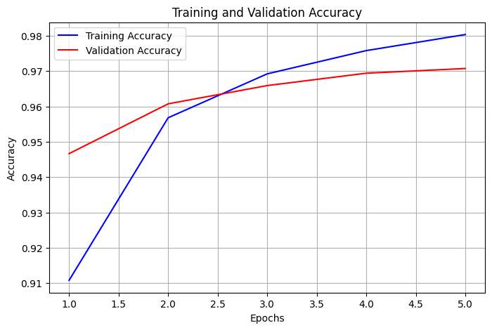

```python
# Baseline
test_loss, test_acc = baseline_model.evaluate(X_features_test, y_labels_test_oh)
print('Validation Accuracy: {:.2f}%'.format(test_acc * 100))

visualize_training_loss(history_baseline)
visualize_training_accuracy(history_baseline)
```

## 9.2 Overfitted Neural Model Results

```
Validation Accuracy: 98.10%
```

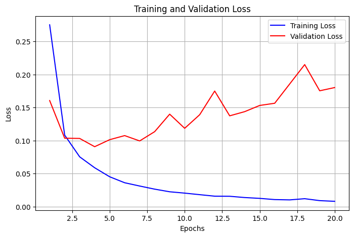

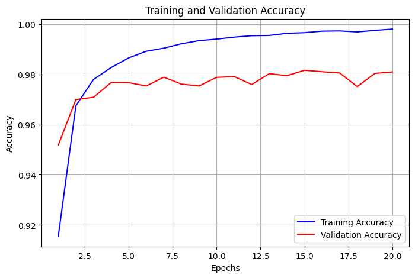

```python
test_loss, test_acc = overfit_model.evaluate(X_features_test, y_labels_test_oh)
print('Validation Accuracy: {:.2f}%'.format(test_acc * 100))

visualize_training_loss(history_overfit)
visualize_training_accuracy(history_overfit)
```

```
Validation Accuracy: 9.58%
```

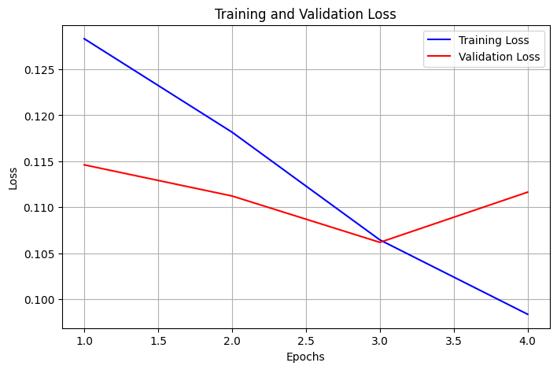

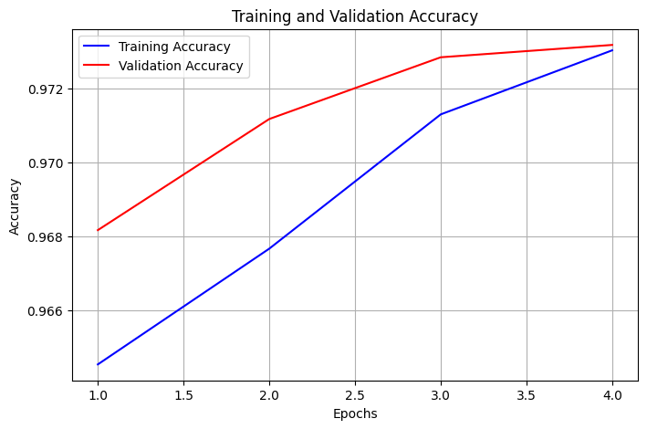

```python
test_loss, test_acc = DropoutModel.evaluate(X_features_test, y_labels_test_oh)
print('Validation Accuracy: {:.2f}%'.format(test_acc * 100))

visualize_training_loss(DropoutModel_history)
visualize_training_accuracy(DropoutModel_history)
```

# 10.Potential Improvements in work to be made

While the models developed in this report has shown some sort of promising result, continous improvement is needed for achieving optimal performance. This could involve eperimenting with different actation functions or exploration into advanced optimization algorithms such as Adam or Nadam, which may offer better convergence rates. In terms of hyperparameter tuning, Bayesian Optimization could be used to systemically search for the optimal set of hyperparamters in a more efficient manner than grid or random search althought it may in which be limited via the scope of this assignment.

Thats all, till next time!

# 11.References

References Chollet, F. (2019). Chapter 4: Fundamentals of Machine Learning. In Deep Learning with Python. Manning Publications. Available at: https://livebook.manning.com/book/deep-learning-with-python/chapter-4/161 [Accessed February 2024].

TensorFlow. (n.d.). MNIST Dataset. TensorFlow Datasets. Available at: https://www.tensorflow.org/datasets/catalog/mnist [Accessed March 2024].

DataRobot. (n.d.). Training, Validation and Holdout. Available at: https://www.datarobot.com/wiki/training-validation-holdout/ [Accessed March 2024].

PenPencil. (2023). What is the Difference Between Training Loss, Validation Loss, and Evaluation Loss? Medium. Available at: https://medium.com/@penpencil.blr/what-is-the-difference-between-training-loss-validation-loss-and-evaluation-loss-c169ddeccd59 [Accessed March 2024].

Brownlee, J. (2022). A Gentle Introduction to Dropout for Regularizing Deep Neural Networks. Machine Learning Mastery. Available at: https://machinelearningmastery.com/dropout-regularization-deep-learning-models-keras/ [Accessed March 2024].

Simplilearn. (2023). Regularization in Machine Learning. Available at: https://www.simplilearn.com/tutorials/machine-learning-tutorial/regularization-in-machine-learning [Accessed March 2024].